# 政治学方法論 I：ロジスティック回帰分析（1）

矢内 勇生

December 3, 2014

### 準備

説明のために『Stataによる計量政治学』（浅野正彦, 矢内勇生. 2013）で使用されているデータ（hr96-09.dta） を使う。 まず、このデータを読み込む（データへのパスは各自の状況に応じて変えること。ここでは、RStudioのプロジェクトを利用していて、プロジェクトが存在するフォルダ内にdata という名前のフォルダがあり、その中にデータセットが保存されていると仮定している）。

```r
require(foreign)
HR <- read.dta("data/hr96-09.dta")
#head(HR)
#tail(HR)
```

衆議院議員経験があることを表すダミー変数を作る。

```r
HR$experience <- as.numeric(HR$status=="incumbent" | HR$status=="moto")
```

選挙費用を100万円単位で測定する変数を作る。

```r
HR$expm <- HR$exp / 10^6
```

小選挙区での当落を表すダミー変数を作る。

```r
HR$wlsmd <- as.numeric(HR$wl=="win")
```

2009年の結果だけ抜き出し、HR09として保存する。

```r
HR09 <- subset(HR, year==2009)
```

expが欠測の個体が1つあるので、（とりあえず）除外しておく。

```r
HR09 <- na.omit(HR09)
```

**arm** パッケージを使うので、インストール済みでない場合はインストールする。

```r
install.packages("arm")
```

## ロジスティック関数（逆ロジット関数）

まず、ロジスティック関数（ロジット関数の逆関数）をRで定義してみよう。 `function()` を使えば、自分で関数を作ることができる。

```r
invlogit <- function(x){ ## ロジスティック関数を定義する
    ## 引数：x = 数値ベクトル
    ## 返り値：y
    y <- 1 / (1 + exp(-x))
    return(y)
}
```

これで`invlogit()` 関数（ロジスティック関数）ができた。

## 説明変数が1つのロジスティック回帰

例として、2009年の衆院選データを用い、選挙費用（expm, 単位100万円）で衆院選小選挙区での当落 (wlsmd) を説明するモデルを考える。このモデルを式で表すと、 $\mathrm{Pr}(\text{当選}) = \mathrm{logit}^{-1}(\alpha + \beta \text{選挙費用})$ となる。

まず、2つの変数の関係を図示してみよう。

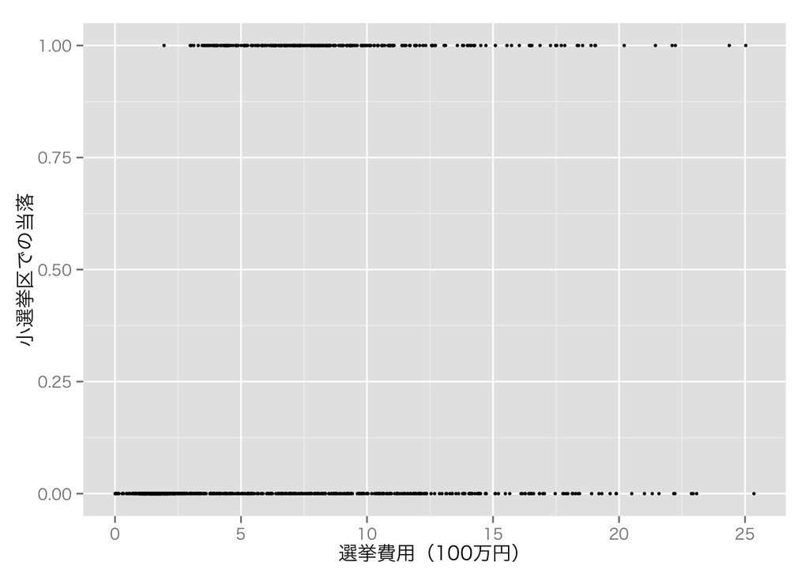

```r
require(ggplot2)
theme_set(theme_gray(base_size=12, base_family="HiraKakuProN-W3"))
p <- ggplot(HR09, aes(x=expm, y=wlsmd)) + geom_point(size=1)
p <- p + xlab("選挙費用（100万円）") + ylab("小選挙区での当落")
print(p)
```

これに（無理やり）OLSを当てはめると、

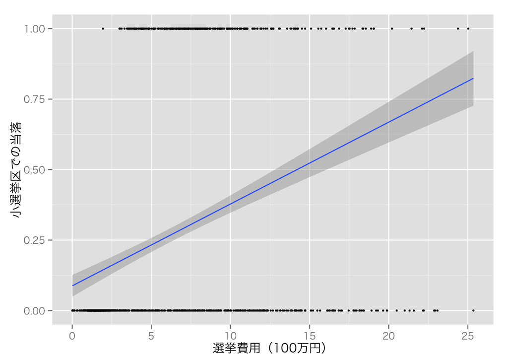

```r
print(p + geom_smooth(method="lm"))
```

となる。

Rでロジスティック回帰分析を行うには`glm()` を使う。 この関数は、一般化線形回帰モデル (Generalized Linear Models: GLM) を当てはめるための関数で、ロジスティック回帰以外でも頻繁に使う関数である。 この関数をロジスティック回帰分析に使うには、引数**family** に**binomial(link=“logit”)**を指定する。

```r
fit1 <- glm(wlsmd ~ expm, data=HR09, family=binomial(link="logit"))
require(arm)
display(fit1)
```

```
## glm(formula = wlsmd ~ expm, family = binomial(link = "logit"),
##     data = HR09)
##             coef.est coef.se
## (Intercept) -2.00     0.13
## expm         0.14     0.01
## ---
##   n = 1124, k = 2
##   residual deviance = 1184.1, null deviance = 1300.1 (difference = 116.0)
```

これで、推定が実行できた。

問題：推定値はどう解釈する？

次に、成功確率の予測値を求めよう。 予測値を求めるには、OLSのときと同様、`predict()` を使えばよい。 ただし、`predict()`のデフォルトでは、線形予測子の測定単位で予測値を返す。 ロジスティック回帰の線形予測子$X\beta$ は対数オッズスケール $(-\infty, \infty)$ なので、 `predict(fit1)`とすると、成功確率が返ってこない（各自で確かめてみること）。 私たちが欲しいのは確率なので、**type=“response”** を指定し、応答変数の測定単位で値を得る（ここで、応答 [response] と考えられているのは、当落そのものではなく、当選確率であることに注意）。

```r
HR09$pred <- predict(fit1, type="response")
```

これを図示してみよう。

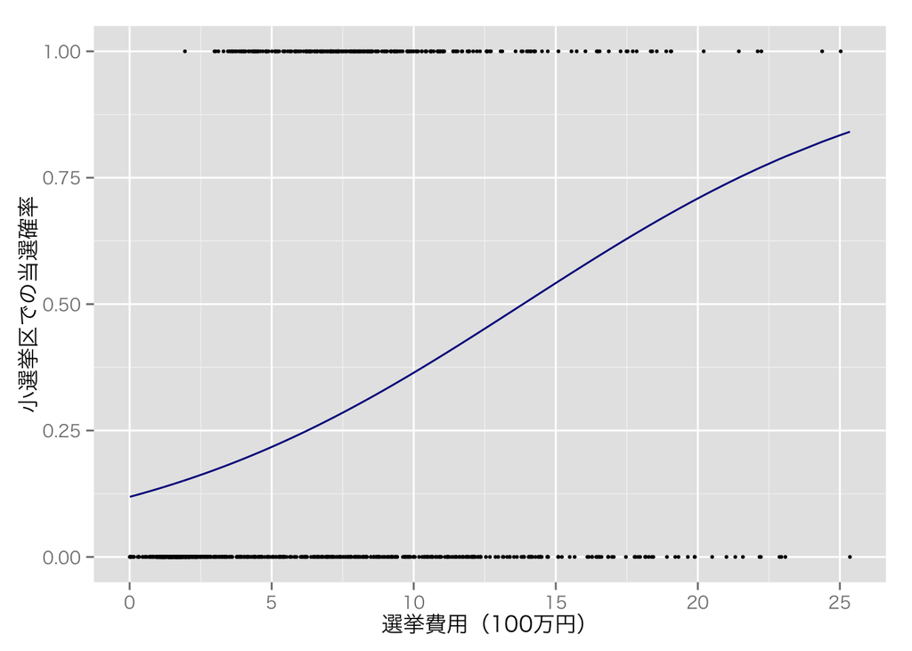

```r
p <- ggplot(HR09, aes(x=expm)) + geom_point(aes(y=wlsmd), size=1) +
    geom_line(aes(y=pred), color="darkblue")
p <- p + xlab("選挙費用（100万円）") + ylab("小選挙区での当選確率")
print(p)
```

あるいは、ggplot2の機能を利用して、

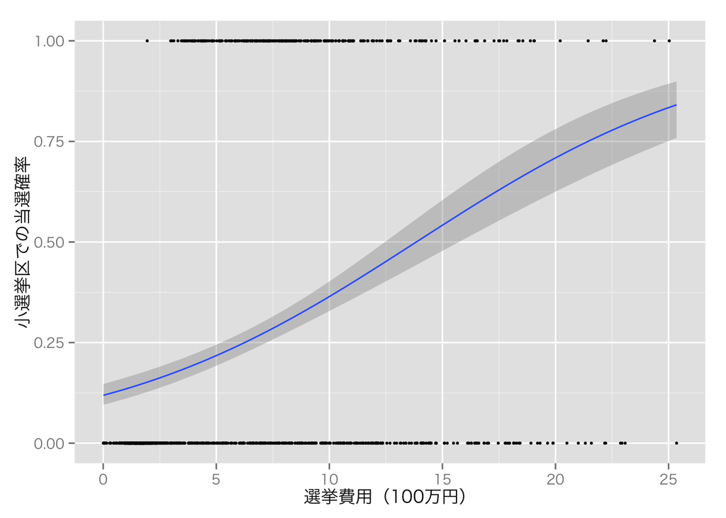

```r
p <- ggplot(HR09, aes(x=expm, y=wlsmd)) + geom_point(size=1) +
    geom_smooth(method="glm", family="binomial")
p <- p + xlab("選挙費用（100万円）") + ylab("小選挙区での当選確率")
print(p)
```

## 説明変数が2つ以上のロジスティック回帰

説明変数が増えても、基本的な分析法は変わらない。 先ほどまでのモデルに、過去の当選回数 (previous) という説明変数を加えてみよう。

ロジスティック回帰を当てはめると、次のような結果が得られる。

```r
fit2 <- glm(wlsmd ~ expm + previous, data=HR09,
            family=binomial(link="logit"))
display(fit2)
```

```
## glm(formula = wlsmd ~ expm + previous, family = binomial(link = "logit"),
##     data = HR09)
##             coef.est coef.se
## (Intercept) -2.04     0.13
## expm         0.04     0.02
## previous     0.36     0.04
## ---
##   n = 1124, k = 3
##   residual deviance = 1071.7, null deviance = 1300.1 (difference = 228.4)
```

問題：この推定結果をどう解釈する？

この結果を図示したいが、説明変数が複数あるので、先ほどのように簡単に図示することはできない。 選挙費用の効果は統計的に有意でない（ただし、符号は期待通り正）ので、選挙費用を平均値に固定し、過去の当選回数と当選確率の関係を図示してみよう。

選挙費用が平均値のときの当選確率の予測値は次のように求める。

```r
n <- dim(HR09)[1]
HR09$pred2 <- predict(fit2, type="response",
                      list(previous=HR09$previous,
                           expm=rep(mean(HR09$expm), n)
                           )
                      )
```

これを図示しよう。

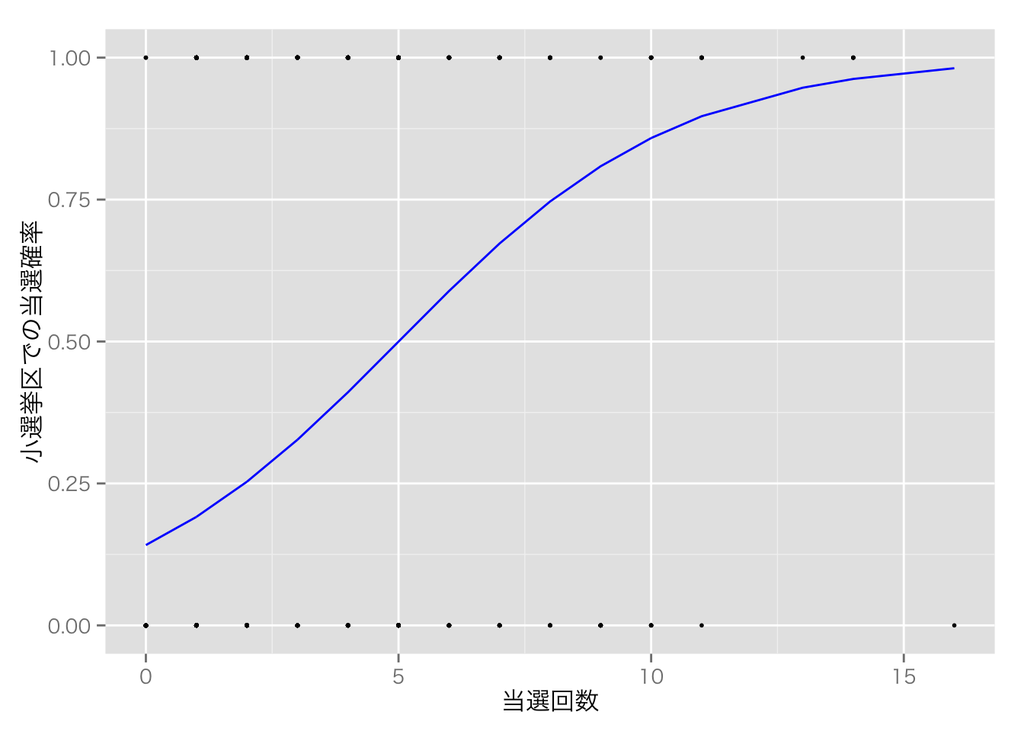

```r
p <- ggplot(HR09, aes(x=previous)) + geom_point(aes(y=wlsmd), size=1) +
    geom_line(aes(y=pred2), color="blue")
p <- p + xlab("当選回数") + ylab("小選挙区での当選確率")
print(p)
```

これに信頼区間を加えるには、まず各予測値の標準誤差を求める。

```r
HR09$se2 <- predict(fit2, type="response",
                      list(previous=HR09$previous,
                           expm=rep(mean(HR09$expm), n)
                           ),
                      se.fit=TRUE)$se.fit
```

```r
HR09$fit2.lb <- with(HR09, pred2 - 2*se2)
HR09$fit2.ub <- with(HR09, pred2 + 2*se2)
```

もとめた区間を図示しよう。先ほど描いた図に信頼区間を加えるだけなので、作成済みの図*p*を再利用する。ただし、データセットHR09に新たな変数を加えたので、データセットをアップデートする。 データのアップデートは `%+%` で行う。

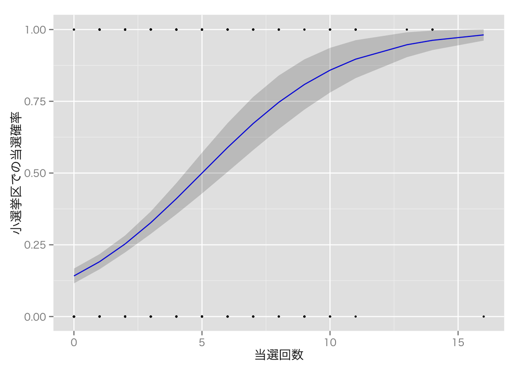

```r
p %+% HR09 + geom_ribbon(aes(ymin=fit2.lb, ymax=fit2.ub), alpha=0.2)
```

浅野・矢内『Stataによる計量政治学』の[第14章](http://www2.kobe-u.ac.jp/~yyanai/jp/quant-methods-stata/R/ch14withR.html) も参照。

授業の内容に戻る